# 613 Lab 3: Interactions & Simple Slopes

```r
library(rio)
library(tidyverse)
library(broom)
# install.packages("reghelper")
library(reghelper)

options(scipen=999)
```

# Interactions in Multiple Regression

- Interactions between continuous predictors
- Interactions between categorical predictors
- Interactions between continuous and categorical predictors

Today, we’ll be looking at an interaction between two continuous predictors.

## Research Scenario

*For her masters project, a grad student wants to see whether the time students spend studying (`time`) interacts with test anxiety (`anx`) to predict students’ test performance (`perf`).*

### Import the Data

```r
simple_slopes_df <- import("613_Lab03_simple_slopes.sav") %>%
  janitor::clean_names()
```

Let’s take a look at the data that we imported from an SPSS file.

```r
head(simple_slopes_df)
```

|  | perf | anx | time |
| --- | --- | --- | --- |
| 1 | 60 | 1 | 1.35 |
| 2 | 60 | 1 | 1.80 |
| 3 | 65 | 1 | 1.80 |
| 4 | 65 | 2 | 1.80 |
| 5 | 70 | 1 | 2.25 |
| 6 | 85 | 1 | 2.25 |

```r
str(simple_slopes_df)
```

```
## 'data.frame':    73 obs. of  3 variables:
##  $ perf: num  60 60 65 65 70 85 70 75 75 75 ...
##   ..- attr(*, "format.spss")= chr "F8.2"
##  $ anx : num  1 1 1 2 1 1 2 1 1 1 ...
##   ..- attr(*, "format.spss")= chr "F8.2"
##  $ time: num  1.35 1.8 1.8 1.8 2.25 2.25 2.7 2.7 3.15 3.15 ...
##   ..- attr(*, "format.spss")= chr "F8.2"
##   ..- attr(*, "display_width")= int 10
```

Q: What is the outcome variable (i.e., DV)?  
A:

Q: What are the predictors (i.e., X1 and X2)?  
A:

Q: Should we center the predictors before computing the interaction term? If so, which variables?  
A:

Q: How would you write the regression equation for this scenario? A:

## Step 1: Center Predictors

To create mean-centered predictors, we’ll take the raw values and subtract the mean from them.

Using the `mutate` function, we can add the new centered versions of each predictor to our dataset.

```r
simple_slopes_df <- simple_slopes_df %>%
  mutate(anx_c = anx - mean(anx, na.rm = TRUE),
         time_c = time - mean(time, na.rm = TRUE))
```

And, we can make sure our centering worked.

```r
simple_slopes_df %>%
  summarize(m_anx_c = mean(anx_c, na.rm = TRUE),
            m_time_c = mean(time_c, na.rm = TRUE)) %>%
  round(5)
```

| m_anx_c | m_time_c |
| --- | --- |
| 0 | 0 |

Yep, looks like it worked; the mean of both variables is zero.

## Step 2: Model the Interaction

Next, we’ll model the interaction. There are a few ways to do this, but the easiest way to do is to simply run an `lm()` and enter our two variables separated by a `*`.

```r
anx_x_time_model <- lm(perf ~  time_c * anx_c, data = simple_slopes_df) # the main effects are automatically included when you include the interaction between two variables

## In other words, the above equation is equivalent to:
anx_x_time_model2 <- lm(perf ~ time_c + anx_c + time_c * anx_c, data = simple_slopes_df)
```

### Look at Model Results

```r
summary(anx_x_time_model)
```

```
##
## Call:
## lm(formula = perf ~ time_c * anx_c, data = simple_slopes_df)
##
## Residuals:
##      Min       1Q   Median       3Q      Max
## -18.8018  -3.8018  -0.5097   3.5747  16.1735
##
## Coefficients:
##              Estimate Std. Error t value             Pr(>|t|)
## (Intercept)   77.8216     0.7406 105.084 < 0.0000000000000002 ***
## time_c         5.8553     0.5077  11.533 < 0.0000000000000002 ***
## anx_c         -2.7301     0.5833  -4.681          0.000013826 ***
## time_c:anx_c  -2.3295     0.4217  -5.524          0.000000547 ***
## ---
## Signif. codes:  0 '***' 0.001 '**' 0.01 '*' 0.05 '.' 0.1 ' ' 1
##
## Residual standard error: 6.293 on 69 degrees of freedom
## Multiple R-squared:  0.6897, Adjusted R-squared:  0.6762
## F-statistic: 51.11 on 3 and 69 DF,  p-value: < 0.00000000000000022
```

You can also make a nice parameter table using `broom::tidy()`

```r
param_table <- anx_x_time_model %>%
  tidy(conf.int = TRUE) %>%
  janitor::clean_names()

knitr::kable(param_table,
             caption = "Parameter Table Predicting Performance from Anxiety X Time",
             digits = c(NA, 2, 2, 2, 5, 2, 2))
```

Parameter Table Predicting Performance from Anxiety X Time

| term | estimate | std_error | statistic | p_value | conf_low | conf_high |
| --- | --- | --- | --- | --- | --- | --- |
| (Intercept) | 77.82 | 0.74 | 105.08 | 0.00000 | 76.34 | 79.30 |
| time_c | 5.86 | 0.51 | 11.53 | 0.00000 | 4.84 | 6.87 |
| anx_c | -2.73 | 0.58 | -4.68 | 0.00001 | -3.89 | -1.57 |
| time_c:anx_c | -2.33 | 0.42 | -5.52 | 0.00000 | -3.17 | -1.49 |

Q: Does the effect of time spent studying depend on one’s standing on anxiety?  
A:

Q: What does the intercept mean (using the value in your answer)? A:

Q: What about the estimate for anxiety?  
A:

Q: What about the estimate for time?  
A:

Q: What about the time X anxiety interaction? A:

## Step 3: Plot the Interaction

Next we’ll unpack what the interaction means by plotting simple slopes. Let’s specifically examine the question of whether the relationship between time and test performance varies depending on level of anxiety (you could also examine whether the relationship between anxiety and test performance varies depending on level of time).

Specifically, let’s get simple slopes for time at different (average) levels of anxiety. To do this, we’ll plot a line for the relationship between time and test performance for people high in anxiety (i.e., 1 SD above the mean), average levels of anxiety (i.e., at the mean), and low in anxiety (i.e., 1 SD below the mean).

### Calculate Simple Intercept & Slope

#### Step 3a: Extract Regression Coefficients from the Model

You can find the model coefficients stored in the `coefficients` component of the model output.

```r
anx_x_time_model$coefficients
```

```
##  (Intercept)       time_c        anx_c time_c:anx_c
##    77.821563     5.855321    -2.730078    -2.329481
```

```r
# How do we get the individual values? INDEXING!

b0 <- anx_x_time_model$coefficients[1]
b_time <- anx_x_time_model$coefficients[2] # b1
b_anx <- anx_x_time_model$coefficients[3] # b2
b_anx_x_time <- anx_x_time_model$coefficients[4] # b3

# Make sure the correct values were stored

b0
```

```
## (Intercept)
##    77.82156
```

```r
b_time
```

```
##   time_c
## 5.855321
```

```r
b_anx
```

```
##     anx_c
## -2.730078
```

```r
b_anx_x_time
```

```
## time_c:anx_c
##    -2.329481
```

#### Step 3b: Calculate Intercepts and Simple Slopes of Time

Next, we’ll calculate the intercepts and time slopes for individuals at low, middle, and high levels of anxiety. Before we do that, we’ll need to get low, medium, and high levels of anxiety, which is generally 1 SD below the mean, the mean, and 1 SD above the mean respectively.

##### Get Low, Mid, & High values of Anxiety

```r
sd(simple_slopes_df$anx_c)
```

```
## [1] 1.305211
```

```r
low_anx <- mean(simple_slopes_df$anx_c, na.rm = TRUE) - sd(simple_slopes_df$anx_c, na.rm = TRUE)
mid_anx <- mean(simple_slopes_df$anx_c, na.rm = TRUE)
high_anx <-  mean(simple_slopes_df$anx_c, na.rm = TRUE) + sd(simple_slopes_df$anx_c, na.rm = TRUE)
```

The full regression equation is: * y = b0 + b1 * time_c + b2 * anx_c + b3 * (time_c*anx_c)* y = b0 + b_time * time_c + b_anx * anx_c + b_anx_x_time * (time_c * anx_c)

We’ll be plugging in specific values for anx_c (-1SD, mean, +1SD) to solve for the simple slopes between time and performance at each level of anxiety.

The intercepts for the simple slopes of time are: * y = b0 + b2 * anx_level * y = b0 + b_anx * anx_level

And the slopes for the simple slopes of time are: * y = b1 + (b3 * anx_level) * y = b_time + (b_anx_x_time * anx_level)

where you replace anx_level with low_anx, mid_anx, or high_anx

##### Calculate The simple slopes and intercepts

```r
intercepts <- c(b0 + (b_anx*low_anx),
                b0 + (b_anx*mid_anx),
                b0 + (b_anx*high_anx))

slopes <- c(b_time + (b_anx_x_time*low_anx),
            b_time + (b_anx_x_time*mid_anx),
            b_time + (b_anx_x_time*high_anx))

# create the level & column labels to make things easy to check
anx_levels <- c("low","mid","high")

# put them all together into a dataframe
int_plot_df <- data.frame(anx_levels,
                         intercepts,
                         slopes)
int_plot_df
```

| anx_levels | intercepts | slopes |
| --- | --- | --- |
| low | 81.38489 | 8.895786 |
| mid | 77.82156 | 5.855321 |
| high | 74.25823 | 2.814856 |

##### Step 3c: Plot!

Finally, we’ll make the plot using `ggplot` and a few different `geoms`, including `geom_point()`, `geom_abline()`

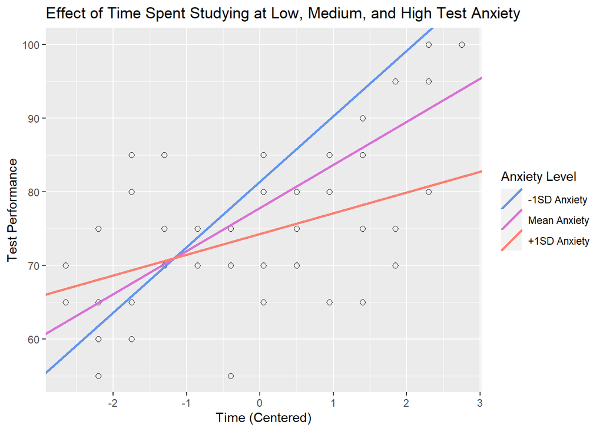

```r
ggplot(simple_slopes_df, aes(x = time_c, y = perf)) + # time on X, performance on Y
  geom_point(stat = "identity", shape = 1, size = 2) +  # add points for scatterplot
  # next we'll add the lines for each level of support, using geom_abline (you specify intercept and slope)
  geom_abline(aes(intercept = int_plot_df$intercepts[1], slope = int_plot_df$slopes[1],
                  colour = "-1SD Anxiety"), size = 1) +
  geom_abline(aes(intercept = int_plot_df$intercepts[2], slope = int_plot_df$slopes[2],
                  colour = "Mean Anxiety"), size = 1) +
  geom_abline(aes(intercept = int_plot_df$intercepts[3], slope = int_plot_df$slopes[3],
                  colour = "+1SD Anxiety"), size = 1) +
  scale_color_manual(values = c("-1SD Anxiety" = 'cornflower blue', "Mean Anxiety" = 'orchid', "+1SD Anxiety" = 'salmon')) +
  labs(title = "Effect of Time Spent Studying at Low, Medium, and High Test Anxiety",
       x = "Time (Centered)", y = "Test Performance", colour = "Anxiety Level")
```

Q: What do you make of the interaction?  
A:

## Step 4: Testing Significance of Simple Slope

Q: Which of the simple slopes does it make sense to test first (in this example)? A:

Let’s test the significance of the simple slopes of time spent studying for people with low test anxiety. Recall from lecture that to test a simple slope, we have to calculate the standard error for the simple slope. The Standard error for a simple slope is

$$SE_{b\_at\_x2} = \sqrt{SE^2_{b1} + 2 * X2(cov(b1, b3)) + X2^2SE^2_{b3}}$$

Which we need to calculate the *t* for a simple slope, which is:

$$t_{b\_at\_X2} = \frac{b_1 + b_3X2}{SE_{b\_at\_x2}}$$
For this example: * b1 = b_time * b3 = b_anx_x_time * X2 = anx_c

### Calculate Standard Error

In order to calculate this, we need to get each slope’s variance and the covariance between slopes. As Elliot mentioned in lecture, we can get this in R from the `vcov()` function.

```r
vcov(anx_x_time_model)
```

```
##               (Intercept)       time_c        anx_c time_c:anx_c
## (Intercept)   0.548433449  0.006426194 -0.009201642  -0.03239192
## time_c        0.006426194  0.257741130 -0.037203691  -0.03528067
## anx_c        -0.009201642 -0.037203691  0.340187806   0.05051826
## time_c:anx_c -0.032391920 -0.035280674  0.050518260   0.17783603
```

Recall that, just like a variance-covariance matrix of variables, the principal diagonal contains variances and covariances are on the off-diagonal (symmetrical about the diagonal). We’ll extract the values we need and save them into objects. Note that we can do this either positionally (i.e., the variance for time_c can be retrieved with `vcov(anx_x_time_model)[2,2]`) or by using the row and column names (i.e., the variance for time_c can be retrieved with `vcov(anx_x_time_model)["time_c", "time_c"]`)

```r
se_b1_sq <- vcov(anx_x_time_model)["time_c", "time_c"]
se_b3_sq <- vcov(anx_x_time_model)["time_c:anx_c", "time_c:anx_c"]
cov_b1_b3 <- vcov(anx_x_time_model)["time_c", "time_c:anx_c"]
```

And you might want to verify that it looks right:

```r
se_b1_sq
```

```
## [1] 0.2577411
```

```r
se_b3_sq
```

```
## [1] 0.177836
```

```r
cov_b1_b3
```

```
## [1] -0.03528067
```

And then we just put in the formula we wrote out above and plug in these values to calculate our Standard Error.

```r
se_b_time_low_anx <- sqrt(se_b1_sq + 2*low_anx*cov_b1_b3 + (low_anx)^2*se_b3_sq)
se_b_time_low_anx
```

```
## [1] 0.8079579
```

### Calculate t stat

Next, we’ll divide the slope for time at low levels of anxiety (that we calculated earlier) by its SE to get a t value. Note that this is *t* distributed with $df = N - k - 1$ *(where k is the number of variables)*

```r
int_plot_df[1, 3] # this is where the value of b1 + b3*low_anx is stored
```

```
## [1] 8.895786
```

```r
t_b_time_low_anx <- int_plot_df[1, 3] / se_b_time_low_anx

t_b_time_low_anx
```

```
## [1] 11.01021
```

Next, we’ll get the p value associated with this t value. First we need the *df*:

```r
df <- nrow(simple_slopes_df) - 4 # N - number of parameters (b0, b1, b2, b3)
```

And finally we’ll get the p value:

```r
# pt() provides the probabilities of lying anywhere on the t-distribution

2*pt(t_b_time_low_anx, df, lower.tail = FALSE) # multiplied by 2 because we typically perform two-tailed tests
```

```
## [1] 0.00000000000000007602326
```

Q: Is the simple slope of time spent studying at low levels of test anxiety significant? A:

### Perfoming Simple Slopes Analysis Using the simple_slopes() function

The `simple_slopes()` function from the `reghelper` package can also perform the simple slopes analysis calculations that we just did by hand.

This function tests the simple effects of the highest-order interaction in the regression equation. If there are multiple interactions of the highest order, it tests the simple effects of the interaction term that comes first.

```r
simple_slopes(anx_x_time_model)
```

| time_c | anx_c | Test Estimate | Std. Error | t value | df | Pr(>\|t\|) |
| --- | --- | --- | --- | --- | --- | --- |
| -1.487879 | sstest | 0.7359085 | 0.7639033 | 0.963353 | 69 | 0.338734544663065184622042 |
| 0 | sstest | -2.7300775 | 0.5832562 | -4.680752 | 69 | 0.000013825589294082997103 |
| 1.487879 | sstest | -6.1960635 | 0.9403236 | -6.589289 | 69 | 0.000000007322182993966558 |
| sstest | -1.305211 | 8.8957852 | 0.8079578 | 11.010211 | 69 | 0.000000000000000076023045 |
| sstest | 0 | 5.8553209 | 0.5076821 | 11.533439 | 69 | 0.000000000000000009391466 |
| sstest | 1.305211 | 2.8148565 | 0.6845443 | 4.112015 | 69 | 0.000106597234305724449573 |

# Importance of Centering

Let’s take a quick look at how centering affects the collinearity of our predictors.

First, you can see that by creating an interaction term and getting the correlations between the variables. Let’s calculate those interaction terms:

```r
simple_slopes_df <- simple_slopes_df %>%
  mutate(time_x_anx = time*anx,
         time_x_anx_c = time_c*anx_c)
```

Then look at the correlation:

```r
simple_slopes_df %>%
  select(anx, time, time_x_anx) %>%
  cor()
```

```
##                   anx       time time_x_anx
## anx        1.00000000 0.09509524  0.6762281
## time       0.09509524 1.00000000  0.7535436
## time_x_anx 0.67622811 0.75354363  1.0000000
```

Q: What do you notice? A:

Now let’s take a look at it for the centered variables:

```r
simple_slopes_df %>%
  select(anx_c, time_c, time_x_anx_c) %>%
  cor()
```

```
##                    anx_c     time_c time_x_anx_c
## anx_c         1.00000000 0.09509524   -0.1887408
## time_c        0.09509524 1.00000000    0.1431481
## time_x_anx_c -0.18874076 0.14314808    1.0000000
```

You can also see this in action by taking a look at the VIF of a model with and without centering

```r
car::vif(lm(perf ~ time * anx, data = simple_slopes_df))
```

```
##      time       anx  time:anx
##  8.647573  6.886183 15.789803
```

And let’s see it for the centered model.

```r
car::vif(anx_x_time_model)
```

```
##       time_c        anx_c time_c:anx_c
##     1.037295     1.053571     1.065884
```

Ahh, much better!